Saltar al contenido principal

dgtrabada

- .rst

# Cuestionario gestión de particiones

# Cuestionario gestión de particiones

1. Conceptos de montaje:

1. ¿Qué es un punto de montaje?

Un lugar donde se almacenan archivos temporales Una ubicación donde se guarda la información de inicio del sistema Una ubicación en el sistema de archivos donde se adjunta otro sistema de archivos Una carpeta oculta en el directorio raíz del sistema

2. ¿Qué es el punto de montaje raíz en Linux?

Un punto de montaje donde se almacenan archivos de arranque Una ubicación temporal para guardar archivos temporales Una carpeta donde se montan dispositivos USB El punto de inicio del sistema de archivos, marcado como /

3. ¿Cuál es el propósito del directorio /mnt?

Almacenar archivos temporales del sistema Servir de lugar para montar temporalmente sistemas de archivos adicionales Almacenar archivos multimedia Guardar copias de seguridad del sistema

4. ¿Qué sucede si intentas desmontar un punto de montaje que está en uso?

El proceso se completa sin problemas Recibirás un mensaje de error indicando que el dispositivo está ocupado El sistema se reiniciará automáticamente El punto de montaje se desmontará automáticamente

5. ¿Cuál es el propósito del directorio /lost+found?

Almacenar archivos que se han perdido en el sistema Almacenar copias de seguridad del sistema Guardar archivos temporales de la shell Almacenar archivos recuperados después de un fallo del sistema de archivos

2. Nombres de particiones:

1. ¿Cómo se llama la primera partición del primer disco duro SATA?

/dev/sda1 /part/1 No tiene nombre hasta que se monta

2. ¿Cómo se llama la primera partición del segundo disco duro SATA?

/dev/sdb1 /part/2 No tiene nombre hasta que se monta

3. ¿Cómo averiguarías si se encuentra montada en estos momentos?

df -h cat /etc/fstab du

4. ¿Cómo se llama la primera partición del primer disco NVMe?

/dev/nvme0n1p1 /dev/nvme1 /dev/sda1

3. Fíjate en el siguiente pantallazo de GParted:

[figure not shown]

1. ¿Dónde está montado el sistema operativo?

2. ¿Qué sistema de archivos tiene?

4. Fíjate en el siguiente pantallazo de GParted:

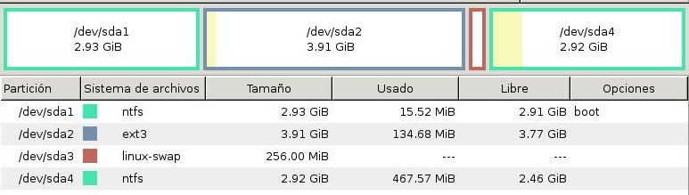

1. ¿Qué comando utilizarías para montar la 2ª partición en /media?

sudo mount /dev/sda2 /media sudo mount nfs /media sudo mount 2par /media

5. Ejecutamos el comando **df -h** y obtenemos:

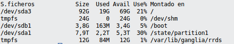

1. Si quisiéramos desmontar la 1ª partición del 2º disco duro, ¿qué comando ejecutaríamos? (escríbelo con sudo)

2. Queremos montar la 2ª partición del 2º disco duro en /media/a, ¿qué comando ejecutamos? (escríbelo con sudo)

6. Montar y desmontar a mano:

1. ¿Cómo montarías la 1ª partición del 1º disco duro en /mnt?

sudo mount /dev/sda1 /mnt sudo mount /dev/sda1 sudo mount /mnt /dev/sda1

2. ¿Cómo la desmontarías? (escríbelo con sudo)

7. Ejecutamos el siguiente comando:

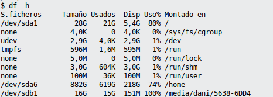

1. ¿Cuántas particiones están montadas?

2. Si quisiéramos desmontar la memoria USB que está montada en /media/dani/5638-6DD4, ¿qué comando ejecutaríamos? (escríbelo con sudo)

8. Ejecutamos los siguientes comandos:

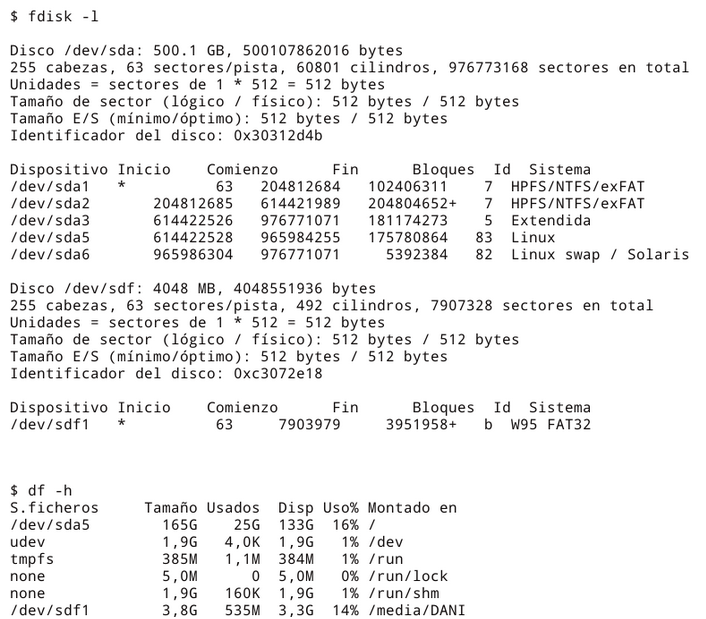

1. ¿Cuántas particiones con sistema de archivos (que se puedan montar) no están montadas?

2. ¿Cuántos discos duros reconoce el sistema?

3. Queremos desmontar la primera partición del disco sdf, ¿qué comando ejecutaríamos? (escríbelo con sudo)

9. Formatear y swap:

1. ¿Qué comando da formato ext4 a la partición /dev/sdb1?

2. ¿Qué comando convierte la partición /dev/sdb2 al formato swap?

3. ¿Cómo activamos esa partición de swap?

4. ¿Y cómo la desactivamos?

5. ¿Qué utilidad detecta, verifica y corrige los errores del sistema de archivos?

10. fdisk y otras utilidades:

1. ¿Qué comando muestra los discos y particiones que hay en el sistema?

fdisk -l fdisk --show ls /dev/discos

2. Dentro de fdisk, ¿qué tecla crea una partición nueva?

3. ¿Y cuál escribe los cambios en el disco?

4. ¿Qué comando muestra información de todos los dispositivos de bloque?

5. ¿Qué comando sirve para determinar el tipo de un archivo?

6. ¿Qué hace dd if=/dev/zero of=/dev/sda bs=512 count=1?

Borra el MBR y su tabla de particiones (escribe ceros en el primer sector) Borra todo el contenido del disco Crea una copia de seguridad del primer disco

7. ¿Qué comando muestra lo que ocupa un directorio?

du -sh df -h free

11. El archivo /etc/fstab. Fíjate en esta línea:

```
$ cat /etc/fstab
/dev/sdb1   /datos   ext4   defaults   0   2
```

1. ¿Qué indica la segunda columna (/datos)?

El punto de montaje El dispositivo La etiqueta del disco

2. ¿Qué indica la tercera columna (ext4)?

El sistema de archivos Las opciones de montaje El tipo de disco

3. ¿A qué equivale la opción defaults?

rw, suid, dev, exec, auto, nouser y async Solo lectura y sin ejecución A no usar ninguna opción

4. ¿Qué opción monta el dispositivo en solo lectura?

5. ¿Qué opción impide ejecutar los binarios almacenados en el dispositivo?

6. ¿Qué indica el último campo (el 2)?

El orden en que fsck revisará la partición durante el arranque El número de copias de seguridad La prioridad de montaje

7. Si ese campo es 0...

La partición no se revisa La partición se revisa la primera No se monta

8. ¿Qué comando monta todo lo que está pendiente en el fstab (útil para probarlo sin reiniciar)?

9. Hoy en el fstab se suele poner UUID=... en lugar de /dev/sdb1. ¿Por qué?

Porque el nombre /dev/sdb1 puede cambiar si se conecta o se quita otro disco, y el UUID no Porque así el disco se monta más rápido Porque /dev/sdb1 solo vale para discos SATA

10. ¿Qué comando muestra el UUID de cada partición?